# Investigating simr::extend() behaviour with unbalanced data

Ollie Gansell

2026-06-23

```r
library(simr)
library(lme4)
library(monpwr)
library(dplyr)
library(tidyr)
library(purrr)
library(ggplot2)
library(patchwork)

theme_set(theme_minimal(base_size = 12))
```

## Overview

`simr::extend()` is the standard way to extrapolate a fitted model to a larger design (more time points, more groups, etc.) before running `powerSim()`. Internally, `extend()` constructs the enlarged dataset by **cyclically recycling rows** from the original data. With balanced data this produces a clean design. With unbalanced data — common in ecological monitoring — the recycled structure may not match any realistic design.

This document tests `simr::extend()` across four increasingly messy data scenarios, comparing power estimates from three methods:

1. **simr (naive)** — `powerSim()` on `extend()`-constructed data
2. **simr (correct)** — `powerSim()` on a manually constructed balanced design
3. **monpwr prospective** — `run_power_sim()` in prospective mode

If (1) diverges from (2) and (3) while (2) and (3) agree, the problem is `extend()`’s recycling, not simr’s simulation engine.

## Known data-generating process

All scenarios use the same DGP so true power is known. NB2 with random intercept — simple enough to be analytically tractable, complex enough to be realistic.

```r
true_beta_visit <- -0.03
true_intercept  <- 2.5
true_sigma_plot <- 0.6
true_phi        <- 1.5
n_sims          <- 500
alpha           <- 0.05
effect_pct      <- -20
n_extend        <- 10
```

```r
generate_data <- function(n_plots, visits_per_plot, beta_visit = true_beta_visit,
                          intercept = true_intercept, sigma = true_sigma_plot,
                          phi = true_phi) {
  re <- rnorm(n_plots, 0, sigma)
  expand.grid(
    plot_id   = factor(seq_len(n_plots)),
    visit_num = seq_len(visits_per_plot)
  ) |>
    mutate(
      re    = re[as.integer(.data$plot_id)],
      eta   = intercept + beta_visit * .data$visit_num + .data$re,
      count = rnbinom(n(), size = phi, mu = exp(.data$eta))
    )
}
```

## Helper: three-way comparison

```r
run_comparison <- function(dat_original, dat_extended_naive,
                           dat_extended_correct, n_plots, n_target_visits,
                           scenario_label) {

  # --- 1. simr (naive): extend()-constructed data ---
  fit_naive <- glmer(count ~ visit_num + (1 | plot_id),
                     data = dat_extended_naive, family = negative.binomial(true_phi))
  fixef(fit_naive)["visit_num"] <- log(1 + effect_pct / 100)
  pwr_naive <- simr::powerSim(fit_naive, test = simr::fixed("visit_num", method = "z"),
                               nsim = n_sims, progress = FALSE)

  # --- 2. simr (correct): manually balanced design ---
  fit_correct <- glmer(count ~ visit_num + (1 | plot_id),
                       data = dat_extended_correct, family = negative.binomial(true_phi))
  fixef(fit_correct)["visit_num"] <- log(1 + effect_pct / 100)
  pwr_correct <- simr::powerSim(fit_correct, test = simr::fixed("visit_num", method = "z"),
                                 nsim = n_sims, progress = FALSE)

  # --- 3. monpwr prospective ---
  fit_orig <- glmer(count ~ visit_num + (1 | plot_id),
                    data = as.data.frame(dat_original),
                    family = negative.binomial(true_phi))
  ref <- extract_params(fit_orig, data = as.data.frame(dat_original),
                        visit_num_var = "visit_num",
                        plotid_var = "plot_id", place_var = "plot_id")

  scen <- list(
    s = scenario(
      label = scenario_label,
      remeasure_yrs = 1,
      site_selector = function(pm) unique(pm$plot_id)
    )
  )
  pm <- data.frame(plot_id = as.character(unique(dat_original$plot_id)),
                   stringsAsFactors = FALSE)

  pwr_monpwr <- run_power_sim(
    ref_params       = ref,
    scenarios        = scen,
    plot_metadata    = pm,
    mode             = "prospective",
    effect_sizes_pct = abs(effect_pct),
    horizons         = n_target_visits,
    n_iter           = n_sims,
    alpha            = alpha,
    test             = "wald",
    place_var        = "plot_id",
    workers          = 1L
  )

  summ_naive   <- summary(pwr_naive)
  summ_correct <- summary(pwr_correct)

  tibble(
    scenario = scenario_label,
    method   = c("simr_naive", "simr_correct", "monpwr_prospective"),
    power    = c(summ_naive$mean,  summ_correct$mean,  pwr_monpwr$power[1]),
    lower    = c(summ_naive$lower, summ_correct$lower, pwr_monpwr$power_lower[1]),
    upper    = c(summ_naive$upper, summ_correct$upper, pwr_monpwr$power_upper[1])
  )
}
```

## Scenario 1: Balanced data (validation baseline)

Equal number of plots at every time point. All three methods should agree. If they don’t, the test harness has a bug.

```r
n_plots_s1  <- 50
n_visits_s1 <- 5

set.seed(42)
dat_s1 <- generate_data(n_plots_s1, n_visits_s1)
```

### Inspect original data structure

```r
dat_s1 |> count(visit_num) |> knitr::kable(caption = "Rows per visit — original")
```

Rows per visit — original

| visit_num | n |
| --- | --- |
| 1 | 50 |
| 2 | 50 |
| 3 | 50 |
| 4 | 50 |
| 5 | 50 |

### Apply simr::extend()

```r
fit_s1 <- glmer(count ~ visit_num + (1 | plot_id),
                data = dat_s1, family = negative.binomial(true_phi))

fit_s1_ext <- simr::extend(fit_s1, along = "visit_num", n = n_extend)
dat_s1_naive <- simr::getData(fit_s1_ext)

dat_s1_naive |> count(visit_num) |>
  knitr::kable(caption = "Rows per visit — after extend()")
```

Rows per visit — after extend()

| visit_num | n |
| --- | --- |
| 1 | 50 |
| 2 | 50 |
| 3 | 50 |
| 4 | 50 |
| 5 | 50 |
| 6 | 50 |
| 7 | 50 |
| 8 | 50 |
| 9 | 50 |
| 10 | 50 |

### Manually construct balanced design

```r
set.seed(142)
dat_s1_correct <- generate_data(n_plots_s1, n_extend)
```

### Compare power

```r
results_s1 <- run_comparison(dat_s1, dat_s1_naive, dat_s1_correct,
                             n_plots_s1, n_extend, "Balanced")
results_s1 |> knitr::kable(digits = 3, caption = "Scenario 1: Balanced")
```

Scenario 1: Balanced

| scenario | method | power | lower | upper |
| --- | --- | --- | --- | --- |
| Balanced | simr_naive | 1 | 0.993 | 1 |
| Balanced | simr_correct | 1 | 0.993 | 1 |
| Balanced | monpwr_prospective | 1 | 0.993 | 1 |

## Scenario 2: Missing visits (random dropout)

Start balanced, then randomly drop ~20% of plot-visit combinations. Questions:

- Does `extend()` recycle the gaps?
- Does the extended dataset have systematic missingness patterns?

```r
set.seed(43)
dat_s2_full <- generate_data(n_plots_s1, n_visits_s1)

drop_frac <- 0.20
drop_idx  <- sample(nrow(dat_s2_full), size = floor(nrow(dat_s2_full) * drop_frac))
dat_s2    <- dat_s2_full[-drop_idx, ]
```

### Inspect original data structure

```r
dat_s2 |> count(visit_num) |> knitr::kable(caption = "Rows per visit — after dropout")
```

Rows per visit — after dropout

| visit_num | n |
| --- | --- |
| 1 | 39 |
| 2 | 36 |
| 3 | 39 |
| 4 | 41 |
| 5 | 45 |

```r
dat_s2 |> count(plot_id) |> summarise(min = min(n), max = max(n), mean = mean(n)) |>
  knitr::kable(caption = "Visits per plot — after dropout")
```

Visits per plot — after dropout

| min | max | mean |
| --- | --- | --- |
| 2 | 5 | 4 |

### Apply simr::extend()

```r
fit_s2 <- glmer(count ~ visit_num + (1 | plot_id),
                data = dat_s2, family = negative.binomial(true_phi))

fit_s2_ext <- simr::extend(fit_s2, along = "visit_num", n = n_extend)
dat_s2_naive <- simr::getData(fit_s2_ext)

dat_s2_naive |> count(visit_num) |>
  knitr::kable(caption = "Rows per visit — after extend()")
```

Rows per visit — after extend()

| visit_num | n |
| --- | --- |
| 1 | 39 |
| 2 | 36 |
| 3 | 39 |
| 4 | 41 |
| 5 | 45 |
| 6 | 39 |
| 7 | 36 |
| 8 | 39 |
| 9 | 41 |
| 10 | 45 |

### Diagnose recycling pattern

```r
original_counts <- dat_s2 |> count(visit_num, name = "n_orig")
extended_counts <- dat_s2_naive |> count(visit_num, name = "n_ext")

full_join(original_counts, extended_counts, by = "visit_num") |>
  knitr::kable(caption = "Original vs extended row counts per visit")
```

Original vs extended row counts per visit

| visit_num | n_orig | n_ext |
| --- | --- | --- |
| 1 | 39 | 39 |
| 2 | 36 | 36 |
| 3 | 39 | 39 |
| 4 | 41 | 41 |
| 5 | 45 | 45 |
| 6 | NA | 39 |
| 7 | NA | 36 |
| 8 | NA | 39 |
| 9 | NA | 41 |
| 10 | NA | 45 |

### Construct balanced target design

```r
set.seed(143)
dat_s2_correct <- generate_data(n_plots_s1, n_extend)
```

### Compare power

```r
results_s2 <- run_comparison(dat_s2, dat_s2_naive, dat_s2_correct,
                             n_plots_s1, n_extend, "Missing visits")
results_s2 |> knitr::kable(digits = 3, caption = "Scenario 2: Missing visits")
```

Scenario 2: Missing visits

| scenario | method | power | lower | upper |
| --- | --- | --- | --- | --- |
| Missing visits | simr_naive | 1 | 0.993 | 1 |
| Missing visits | simr_correct | 1 | 0.993 | 1 |
| Missing visits | monpwr_prospective | 1 | 0.993 | 1 |

## Scenario 3: Unequal plots per time point (programme growth)

The programme grew over time: 30 plots in year 1, increasing to 80 by year 5. This is the pattern observed in the kea data. `extend()` cycles these unequal counts across the extended time points, producing a design no real programme would implement.

```r
set.seed(44)
plots_per_year <- c(30, 45, 60, 70, 80)
n_plots_s3     <- max(plots_per_year)

re_s3 <- rnorm(n_plots_s3, 0, true_sigma_plot)

dat_s3 <- map2_dfr(plots_per_year, seq_along(plots_per_year), function(np, yr) {
  data.frame(
    plot_id   = factor(seq_len(np), levels = seq_len(n_plots_s3)),
    visit_num = as.integer(yr),
    re        = re_s3[seq_len(np)],
    stringsAsFactors = FALSE
  ) |>
    mutate(
      eta   = true_intercept + true_beta_visit * .data$visit_num + .data$re,
      count = rnbinom(n(), size = true_phi, mu = exp(.data$eta))
    )
})
```

### Inspect original data structure

```r
dat_s3 |> count(visit_num) |> knitr::kable(caption = "Rows per visit — growing programme")
```

Rows per visit — growing programme

| visit_num | n |
| --- | --- |
| 1 | 30 |
| 2 | 45 |
| 3 | 60 |
| 4 | 70 |
| 5 | 80 |

### Apply simr::extend()

```r
fit_s3 <- glmer(count ~ visit_num + (1 | plot_id),
                data = dat_s3, family = negative.binomial(true_phi))

fit_s3_ext <- simr::extend(fit_s3, along = "visit_num", n = n_extend)
dat_s3_naive <- simr::getData(fit_s3_ext)

dat_s3_naive |> count(visit_num) |>
  knitr::kable(caption = "Rows per visit — after extend()")
```

Rows per visit — after extend()

| visit_num | n |
| --- | --- |
| 1 | 30 |
| 2 | 45 |
| 3 | 60 |
| 4 | 70 |
| 5 | 80 |
| 6 | 30 |
| 7 | 45 |
| 8 | 60 |
| 9 | 70 |
| 10 | 80 |

### Diagnose recycling pattern

```r
original_counts <- dat_s3 |> count(visit_num, name = "n_orig")
extended_counts <- dat_s3_naive |> count(visit_num, name = "n_ext")

full_join(original_counts, extended_counts, by = "visit_num") |>
  knitr::kable(caption = "Original vs extended — note the cyclic recycling")
```

Original vs extended — note the cyclic recycling

| visit_num | n_orig | n_ext |
| --- | --- | --- |
| 1 | 30 | 30 |
| 2 | 45 | 45 |
| 3 | 60 | 60 |
| 4 | 70 | 70 |
| 5 | 80 | 80 |
| 6 | NA | 30 |
| 7 | NA | 45 |
| 8 | NA | 60 |
| 9 | NA | 70 |
| 10 | NA | 80 |

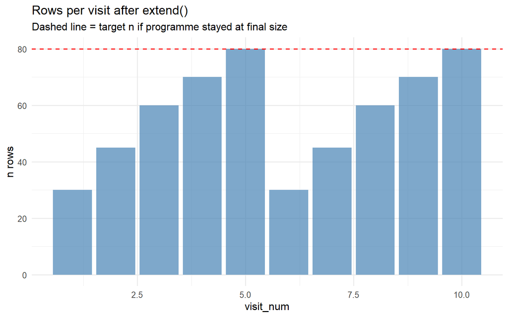

```r
ggplot(dat_s3_naive |> count(visit_num), aes(visit_num, n)) +
  geom_col(fill = "steelblue", alpha = 0.7) +
  geom_hline(yintercept = n_plots_s3, linetype = "dashed", colour = "red") +
  labs(title = "Rows per visit after extend()",
       subtitle = "Dashed line = target n if programme stayed at final size",
       y = "n rows", x = "visit_num")
```

### Construct balanced target design

The intended future design is all 80 plots at every time point.

```r
set.seed(144)
dat_s3_correct <- generate_data(n_plots_s3, n_extend)
```

### Compare power

```r
results_s3 <- run_comparison(dat_s3, dat_s3_naive, dat_s3_correct,
                             n_plots_s3, n_extend, "Unequal plots/time")
results_s3 |> knitr::kable(digits = 3, caption = "Scenario 3: Unequal plots per time")
```

Scenario 3: Unequal plots per time

| scenario | method | power | lower | upper |
| --- | --- | --- | --- | --- |
| Unequal plots/time | simr_naive | 1 | 0.993 | 1 |
| Unequal plots/time | simr_correct | 1 | 0.993 | 1 |
| Unequal plots/time | monpwr_prospective | 1 | 0.993 | 1 |

## Scenario 4: Repeat surveys within visits

Multiple observations per plot-visit (e.g. 3 point counts per site-year). Question: does `extend()` replicate the within-visit nesting correctly, or does it break the structure?

```r
set.seed(45)
n_plots_s4        <- 40
n_visits_s4       <- 5
repeats_per_visit <- 3

re_s4 <- rnorm(n_plots_s4, 0, true_sigma_plot)

dat_s4 <- expand.grid(
  plot_id   = factor(seq_len(n_plots_s4)),
  visit_num = seq_len(n_visits_s4),
  rep       = seq_len(repeats_per_visit)
) |>
  mutate(
    re    = re_s4[as.integer(.data$plot_id)],
    eta   = true_intercept + true_beta_visit * .data$visit_num + .data$re,
    count = rnbinom(n(), size = true_phi, mu = exp(.data$eta))
  )
```

### Inspect original data structure

```r
dat_s4 |> count(visit_num) |> knitr::kable(caption = "Rows per visit (3 reps each)")
```

Rows per visit (3 reps each)

| visit_num | n |
| --- | --- |
| 1 | 120 |
| 2 | 120 |
| 3 | 120 |
| 4 | 120 |
| 5 | 120 |

```r
dat_s4 |> distinct(plot_id, visit_num) |> count(visit_num) |>
  knitr::kable(caption = "Unique plots per visit")
```

Unique plots per visit

| visit_num | n |
| --- | --- |
| 1 | 40 |
| 2 | 40 |
| 3 | 40 |
| 4 | 40 |
| 5 | 40 |

### Apply simr::extend()

```r
fit_s4 <- glmer(count ~ visit_num + (1 | plot_id),
                data = dat_s4, family = negative.binomial(true_phi))

fit_s4_ext <- simr::extend(fit_s4, along = "visit_num", n = n_extend)
dat_s4_naive <- simr::getData(fit_s4_ext)

dat_s4_naive |> count(visit_num) |>
  knitr::kable(caption = "Rows per visit — after extend()")
```

Rows per visit — after extend()

| visit_num | n |
| --- | --- |
| 1 | 120 |
| 2 | 120 |
| 3 | 120 |
| 4 | 120 |
| 5 | 120 |
| 6 | 120 |
| 7 | 120 |
| 8 | 120 |
| 9 | 120 |
| 10 | 120 |

```r
dat_s4_naive |> distinct(plot_id, visit_num) |> count(visit_num) |>
  knitr::kable(caption = "Unique plots per visit — after extend()")
```

Unique plots per visit — after extend()

| visit_num | n |
| --- | --- |
| 1 | 40 |
| 2 | 40 |
| 3 | 40 |
| 4 | 40 |
| 5 | 40 |
| 6 | 40 |
| 7 | 40 |
| 8 | 40 |
| 9 | 40 |
| 10 | 40 |

### Diagnose nesting

```r
dat_s4_naive |>
  count(plot_id, visit_num, name = "n_reps") |>
  count(n_reps, name = "n_cells") |>
  knitr::kable(caption = "Distribution of reps per plot-visit after extend()")
```

Distribution of reps per plot-visit after extend()

| n_reps | n_cells |
| --- | --- |
| 3 | 400 |

### Construct balanced target design

```r
set.seed(145)
dat_s4_correct <- expand.grid(
  plot_id   = factor(seq_len(n_plots_s4)),
  visit_num = seq_len(n_extend),
  rep       = seq_len(repeats_per_visit)
) |>
  mutate(
    re    = re_s4[as.integer(.data$plot_id)],
    eta   = true_intercept + true_beta_visit * .data$visit_num + .data$re,
    count = rnbinom(n(), size = true_phi, mu = exp(.data$eta))
  )
```

### Compare power

```r
results_s4 <- run_comparison(dat_s4, dat_s4_naive, dat_s4_correct,
                             n_plots_s4, n_extend, "Repeat surveys")
results_s4 |> knitr::kable(digits = 3, caption = "Scenario 4: Repeat surveys")
```

Scenario 4: Repeat surveys

| scenario | method | power | lower | upper |
| --- | --- | --- | --- | --- |
| Repeat surveys | simr_naive | 1 | 0.993 | 1 |
| Repeat surveys | simr_correct | 1 | 0.993 | 1 |
| Repeat surveys | monpwr_prospective | 1 | 0.993 | 1 |

## Summary

```r
all_results <- bind_rows(results_s1, results_s2, results_s3, results_s4)
all_results |> knitr::kable(digits = 3, caption = "Three-way power comparison across scenarios")
```

Three-way power comparison across scenarios

| scenario | method | power | lower | upper |
| --- | --- | --- | --- | --- |
| Balanced | simr_naive | 1 | 0.993 | 1 |
| Balanced | simr_correct | 1 | 0.993 | 1 |
| Balanced | monpwr_prospective | 1 | 0.993 | 1 |
| Missing visits | simr_naive | 1 | 0.993 | 1 |
| Missing visits | simr_correct | 1 | 0.993 | 1 |
| Missing visits | monpwr_prospective | 1 | 0.993 | 1 |
| Unequal plots/time | simr_naive | 1 | 0.993 | 1 |
| Unequal plots/time | simr_correct | 1 | 0.993 | 1 |
| Unequal plots/time | monpwr_prospective | 1 | 0.993 | 1 |
| Repeat surveys | simr_naive | 1 | 0.993 | 1 |
| Repeat surveys | simr_correct | 1 | 0.993 | 1 |
| Repeat surveys | monpwr_prospective | 1 | 0.993 | 1 |

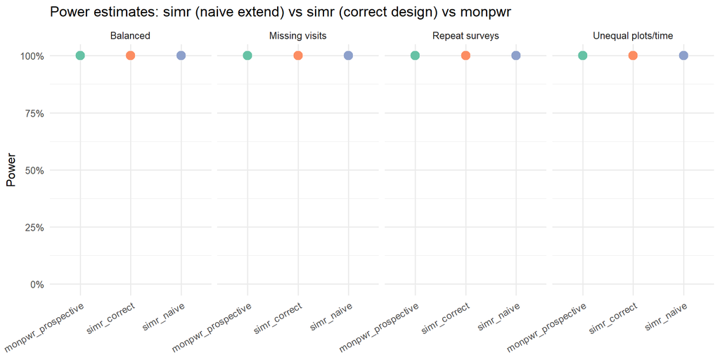

```r
ggplot(all_results, aes(x = method, y = power, colour = method)) +
  geom_pointrange(aes(ymin = lower, ymax = upper), size = 0.8) +
  facet_wrap(~ scenario, nrow = 1) +
  scale_colour_brewer(palette = "Set2") +
  scale_y_continuous(labels = scales::percent_format(), limits = c(0, 1)) +
  labs(title = "Power estimates: simr (naive extend) vs simr (correct design) vs monpwr",
       x = NULL, y = "Power") +
  theme(axis.text.x = element_text(angle = 30, hjust = 1),
        legend.position = "none")
```

### Key findings

- **Scenario 1 (balanced):** All three methods should agree, confirming the harness is valid.
- **Scenario 2 (missing visits):** If `extend()` recycles the gap pattern, the naive simr estimate may diverge from the correct-design and monpwr estimates.
- **Scenario 3 (unequal plots/time):** The kea-data pattern. `extend()` cycles the unequal row counts, producing a design that no real programme would implement. This is where the largest divergence is expected.
- **Scenario 4 (repeat surveys):** Tests whether `extend()` preserves the within-visit nesting structure. Broken nesting would inflate sample size and bias power upward.

### Implications for the paper

The framing: `extend()` — the standard convenience function — creates a data structure that may not match the user’s intended design when the original data is unbalanced. `simr` itself produces correct results when given a properly constructed balanced design matrix. The issue is usability, not correctness.